# Dogeusdt Price Prediction AutoRegressive

Data Source: https://www.cryptodatadownload.com/data/binance/  
Daily Data Dogecoin/usdt from 2019/7/05 to 2025/5/20

# Import Library

```python
import pandas as pd
import numpy as np
import matplotlib.pyplot as plt
from statsmodels.tsa.stattools import adfuller
from statsmodels.graphics.tsaplots import plot_pacf
from statsmodels.tsa.ar_model import AutoReg
from statsmodels.graphics.tsaplots import month_plot, quarter_plot, plot_acf, plot_pacf
from statsmodels.tsa.seasonal import seasonal_decompose
from matplotlib.ticker import MultipleLocator
import scipy.stats as stats
import pylab
import warnings
warnings.filterwarnings('ignore')
```

# Import Data

```python
df = pd.read_csv('Binance_DOGEUSDT_d.csv', index_col='Date', parse_dates=['Date'])
df.sort_index(inplace=True)
df
```

| Date | Unix | Symbol | Open | High | Low | Close | Volume DOGE | Volume USDT | tradecount |
| --- | --- | --- | --- | --- | --- | --- | --- | --- | --- |
| 2019-07-05 | 1.562280e+12 | DOGEUSDT | 0.004490 | 0.004600 | 0.003550 | 0.003870 | 1.928298e+09 | 7.506289e+06 | 18589 |
| 2019-07-06 | 1.562370e+12 | DOGEUSDT | 0.003874 | 0.003943 | 0.003365 | 0.003500 | 1.010744e+09 | 3.692804e+06 | 17250 |
| 2019-07-07 | 1.562460e+12 | DOGEUSDT | 0.003504 | 0.003650 | 0.003400 | 0.003538 | 5.306140e+08 | 1.860353e+06 | 9394 |
| 2019-07-08 | 1.562540e+12 | DOGEUSDT | 0.003538 | 0.003562 | 0.003400 | 0.003458 | 3.084457e+08 | 1.078072e+06 | 4958 |
| 2019-07-09 | 1.562630e+12 | DOGEUSDT | 0.003462 | 0.003582 | 0.003356 | 0.003455 | 2.533756e+08 | 8.785283e+05 | 5690 |
| ... | ... | ... | ... | ... | ... | ... | ... | ... | ... |
| 2025-05-16 | 1.747350e+12 | DOGEUSDT | 0.219400 | 0.230950 | 0.217970 | 0.221110 | 9.915090e+08 | 2.235364e+08 | 845856 |
| 2025-05-17 | 1.747440e+12 | DOGEUSDT | 0.221110 | 0.222250 | 0.210740 | 0.214570 | 8.676143e+08 | 1.873087e+08 | 849009 |
| 2025-05-18 | 1.747530e+12 | DOGEUSDT | 0.214580 | 0.237790 | 0.214020 | 0.233040 | 1.589243e+09 | 3.600241e+08 | 1373019 |
| 2025-05-19 | 1.747610e+12 | DOGEUSDT | 0.233090 | 0.235810 | 0.213880 | 0.224450 | 1.467077e+09 | 3.243041e+08 | 1089047 |
| 2025-05-20 | 1.747700e+12 | DOGEUSDT | 0.224460 | 0.230800 | 0.217680 | 0.226250 | 1.188057e+09 | 2.656155e+08 | 1075439 |

2137 rows × 9 columns

```python
doge = df.copy()
doge
```

| Date | Unix | Symbol | Open | High | Low | Close | Volume DOGE | Volume USDT | tradecount |
| --- | --- | --- | --- | --- | --- | --- | --- | --- | --- |
| 2019-07-05 | 1.562280e+12 | DOGEUSDT | 0.004490 | 0.004600 | 0.003550 | 0.003870 | 1.928298e+09 | 7.506289e+06 | 18589 |
| 2019-07-06 | 1.562370e+12 | DOGEUSDT | 0.003874 | 0.003943 | 0.003365 | 0.003500 | 1.010744e+09 | 3.692804e+06 | 17250 |
| 2019-07-07 | 1.562460e+12 | DOGEUSDT | 0.003504 | 0.003650 | 0.003400 | 0.003538 | 5.306140e+08 | 1.860353e+06 | 9394 |
| 2019-07-08 | 1.562540e+12 | DOGEUSDT | 0.003538 | 0.003562 | 0.003400 | 0.003458 | 3.084457e+08 | 1.078072e+06 | 4958 |
| 2019-07-09 | 1.562630e+12 | DOGEUSDT | 0.003462 | 0.003582 | 0.003356 | 0.003455 | 2.533756e+08 | 8.785283e+05 | 5690 |
| ... | ... | ... | ... | ... | ... | ... | ... | ... | ... |
| 2025-05-16 | 1.747350e+12 | DOGEUSDT | 0.219400 | 0.230950 | 0.217970 | 0.221110 | 9.915090e+08 | 2.235364e+08 | 845856 |
| 2025-05-17 | 1.747440e+12 | DOGEUSDT | 0.221110 | 0.222250 | 0.210740 | 0.214570 | 8.676143e+08 | 1.873087e+08 | 849009 |
| 2025-05-18 | 1.747530e+12 | DOGEUSDT | 0.214580 | 0.237790 | 0.214020 | 0.233040 | 1.589243e+09 | 3.600241e+08 | 1373019 |
| 2025-05-19 | 1.747610e+12 | DOGEUSDT | 0.233090 | 0.235810 | 0.213880 | 0.224450 | 1.467077e+09 | 3.243041e+08 | 1089047 |
| 2025-05-20 | 1.747700e+12 | DOGEUSDT | 0.224460 | 0.230800 | 0.217680 | 0.226250 | 1.188057e+09 | 2.656155e+08 | 1075439 |

2137 rows × 9 columns

# Checking Missing Values

```python
doge.isnull().sum()
```

```
Unix           0
Symbol         0
Open           0
High           0
Low            0
Close          0
Volume DOGE    0
Volume USDT    0
tradecount     0
dtype: int64
```

# Set Frequency

```python
doge = doge.asfreq('d')
```

# Handling Missing Values

```python
doge.isnull().sum()
```

```
Unix           10
Symbol         10
Open           10
High           10
Low            10
Close          10
Volume DOGE    10
Volume USDT    10
tradecount     10
dtype: int64
```

```python
doge = doge.ffill()
```

```python
doge.isnull().sum()
```

```
Unix           0
Symbol         0
Open           0
High           0
Low            0
Close          0
Volume DOGE    0
Volume USDT    0
tradecount     0
dtype: int64
```

# Exploratory Data Analysis Time Series

```python
doge.describe()
```

|  | Unix | Open | High | Low | Close | Volume DOGE | Volume USDT | tradecount |
| --- | --- | --- | --- | --- | --- | --- | --- | --- |
| count | 2.147000e+03 | 2147.000000 | 2147.000000 | 2147.000000 | 2147.000000 | 2.147000e+03 | 2.147000e+03 | 2.147000e+03 |
| mean | 1.654991e+12 | 0.107720 | 0.113127 | 0.102256 | 0.107823 | 1.846214e+09 | 2.898231e+08 | 5.216983e+05 |
| std | 5.355982e+10 | 0.104870 | 0.111966 | 0.097469 | 0.104876 | 4.887770e+09 | 8.910924e+08 | 1.087768e+06 |
| min | 1.562280e+12 | 0.001497 | 0.001643 | 0.001135 | 0.001582 | 2.951775e+07 | 6.364172e+04 | 4.890000e+02 |
| 25% | 1.608640e+12 | 0.004515 | 0.004745 | 0.004146 | 0.004531 | 4.219076e+08 | 1.042272e+07 | 3.285600e+04 |
| 50% | 1.654990e+12 | 0.079500 | 0.082030 | 0.077150 | 0.079620 | 8.294164e+08 | 7.644943e+07 | 1.606740e+05 |
| 75% | 1.701345e+12 | 0.154690 | 0.162215 | 0.147415 | 0.154855 | 1.664297e+09 | 2.174053e+08 | 4.947475e+05 |
| max | 1.747700e+12 | 0.689820 | 0.739950 | 0.600000 | 0.689820 | 1.090740e+11 | 1.759856e+10 | 1.533078e+07 |

DOGE has had a very wide price range, with closing prices ranging from around 0.0016 dollar to around $0.69 dollar.

Volume DOGE and Volume USDT have huge variability (std is very high), which indicates some days had massive trading spikes.

The median prices are much lower than the max values, which indicates that price spikes are rare and skew the data.

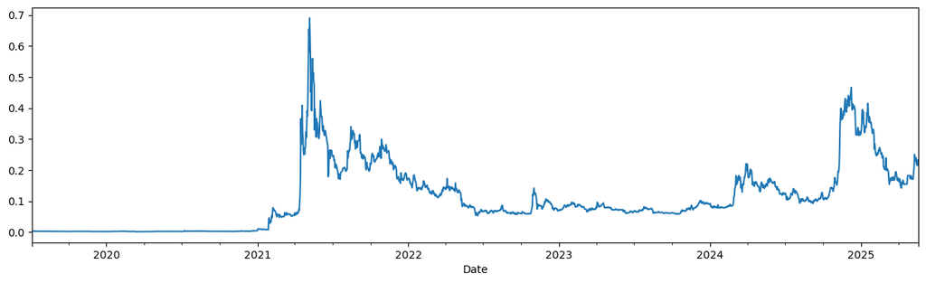

```python
# Daily Closing Price Plot
doge["Close"].plot(figsize=(15,4))
plt.show()
```

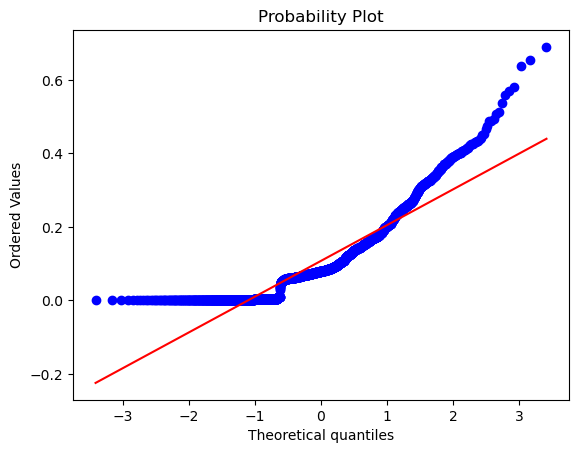

```python
scipy.stats.probplot(doge.Close, plot=pylab)
pylab.show()
```

[output not shown]

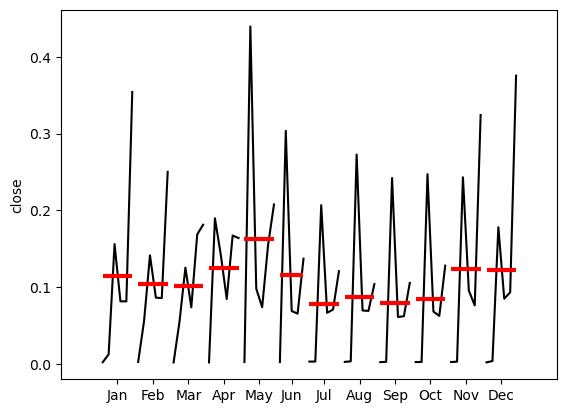

```python
#montly seasonality
month_plot(doge["Close"].resample("ME").mean(),
          ylabel='close')
plt.show()
```

Based on the visible pattern:

```
There might be some seasonal behavior, but it's not strong or consistent.

DOGE closing prices are likely influenced more by external market events than by intrinsic seasonality.
```

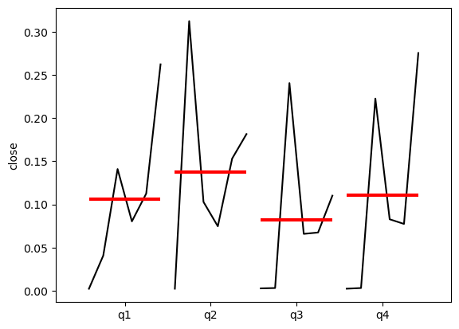

```python
#quarter plot
quarter_plot(doge["Close"].resample("QE").mean(),
          ylabel='close')
plt.show()
```

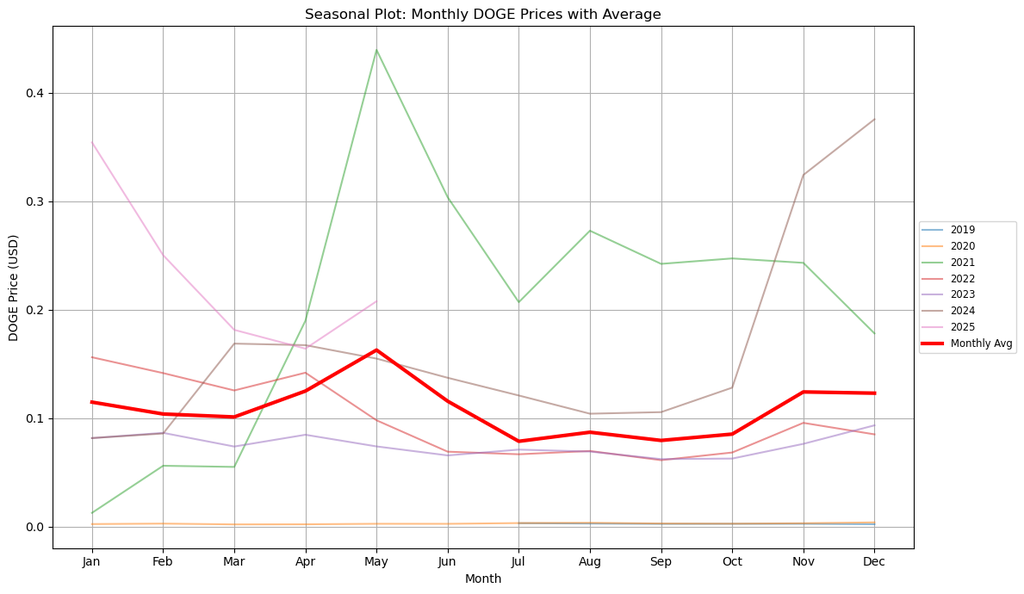

```python
# MONTLY
# Ensure the index is datetime (just in case)
doge.index = pd.to_datetime(doge.index)

# Extract year and month from the index
doge['Year'] = doge.index.year
doge['Month'] = doge.index.strftime('%b')

# Create the pivot table
pivot_df = doge.pivot_table(index='Month', columns='Year', values='Close', aggfunc='mean')

# Reorder the months
month_order = ['Jan', 'Feb', 'Mar', 'Apr', 'May', 'Jun',
               'Jul', 'Aug', 'Sep', 'Oct', 'Nov', 'Dec']
pivot_df = pivot_df.reindex(month_order)

plt.figure(figsize=(12, 7))

for year in pivot_df.columns:
    plt.plot(pivot_df.index, pivot_df[year], label=str(year), alpha=0.5)

monthly_avg = pivot_df.mean(axis=1)
plt.plot(pivot_df.index, monthly_avg, color='red', linewidth=3, label='Monthly Avg')

plt.title('Seasonal Plot: Monthly DOGE Prices with Average')
plt.xlabel('Month')
plt.ylabel('DOGE Price (USD)')
plt.legend(loc='center left', bbox_to_anchor=(1.0, 0.5), fontsize='small')
plt.grid(True)
plt.tight_layout()
plt.show()
```

Some important month:  
**May** stands out with the highest average monthly price — notably in 2021 (green line), when DOGE peaked due to hype and social media (e.g., Elon Musk & SNL event).

**November–December** also shows some upward movement, possibly due to end-of-year trading activity.

**July–September** tends to have lower average prices, indicating a seasonal dip.

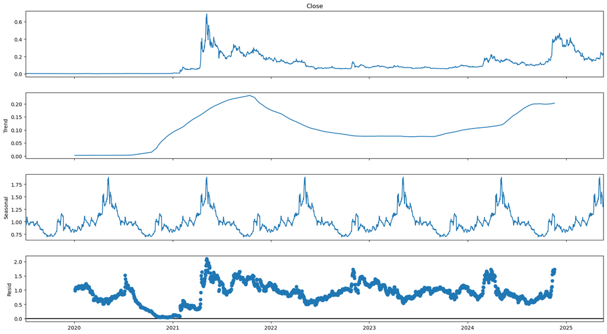

```python
# Seasonal decomposition for df['Adj. Close']
decomposition = seasonal_decompose(doge['Close'],
                                  model = 'mul',
                                  period = 365)
fig = decomposition.plot()
fig.set_size_inches(18, 10)
plt.show()
```

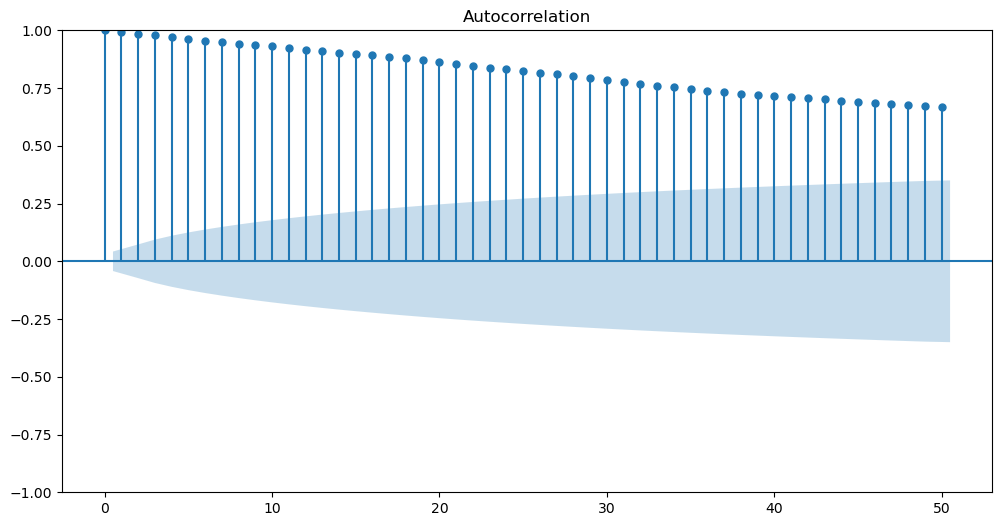

```python
# Plot the ACF of the
fig, ax = plt.subplots(figsize = (12, 6))
plot_acf(doge['Close'], lags = 50, ax = ax)
plt.show()
```

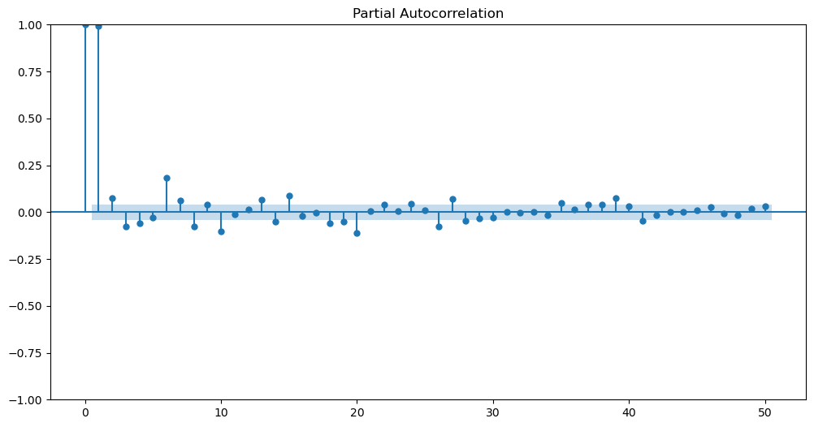

```python
# PACF
fig, ax = plt.subplots(figsize = (12, 6))
plot_pacf(doge['Close'], lags = 50, ax = ax)
plt.show()
```

# Simplifying the dataset

```python
doge.drop(['Unix', 'Symbol', 'Open', 'High','Low','Volume DOGE','Volume USDT','tradecount'], axis=1, inplace=True)
doge
```

| Date | Close | Year | Month |
| --- | --- | --- | --- |
| 2019-07-05 | 0.003870 | 2019 | Jul |
| 2019-07-06 | 0.003500 | 2019 | Jul |
| 2019-07-07 | 0.003538 | 2019 | Jul |
| 2019-07-08 | 0.003458 | 2019 | Jul |
| 2019-07-09 | 0.003455 | 2019 | Jul |
| ... | ... | ... | ... |
| 2025-05-16 | 0.221110 | 2025 | May |
| 2025-05-17 | 0.214570 | 2025 | May |
| 2025-05-18 | 0.233040 | 2025 | May |
| 2025-05-19 | 0.224450 | 2025 | May |
| 2025-05-20 | 0.226250 | 2025 | May |

2147 rows × 3 columns

# Split & Test

```python
size = int(len(doge)*0.8) #80/20 split
doge_train = doge.iloc[:size]
doge_test = doge.iloc[size:]
doge_train.tail()
```

| Date | Close | Year | Month |
| --- | --- | --- | --- |
| 2024-03-12 | 0.16816 | 2024 | Mar |
| 2024-03-13 | 0.16897 | 2024 | Mar |
| 2024-03-14 | 0.17719 | 2024 | Mar |
| 2024-03-15 | 0.16357 | 2024 | Mar |
| 2024-03-16 | 0.14253 | 2024 | Mar |

# Stationarity and differencing

```python
adf_result = adfuller(doge_train.Close)
print("ADF Statistic:", adf_result[0])
print("p-value:", adf_result[1])
if adf_result[1] <= 0.05:
    print("✅ Series is stationary")
else:
    print("⚠️ Series is NOT stationary. Consider differencing.")
```

```
ADF Statistic: -2.660711339831353
p-value: 0.081087137194988
⚠️ Series is NOT stationary. Consider differencing.
```

```python
doge_train['Close_diff'] = doge_train['Close'].diff().dropna()
```

```python
doge_train = doge_train[doge_train['Close_diff'].notna()]
doge_train
```

| Date | Close | Year | Month | Close_diff |
| --- | --- | --- | --- | --- |
| 2019-07-06 | 0.003500 | 2019 | Jul | -0.000370 |
| 2019-07-07 | 0.003538 | 2019 | Jul | 0.000038 |
| 2019-07-08 | 0.003458 | 2019 | Jul | -0.000080 |
| 2019-07-09 | 0.003455 | 2019 | Jul | -0.000004 |
| 2019-07-10 | 0.003342 | 2019 | Jul | -0.000112 |
| ... | ... | ... | ... | ... |
| 2024-03-12 | 0.168160 | 2024 | Mar | -0.013840 |
| 2024-03-13 | 0.168970 | 2024 | Mar | 0.000810 |
| 2024-03-14 | 0.177190 | 2024 | Mar | 0.008220 |
| 2024-03-15 | 0.163570 | 2024 | Mar | -0.013620 |
| 2024-03-16 | 0.142530 | 2024 | Mar | -0.021040 |

1716 rows × 4 columns

```python
adf_result = adfuller(doge_train.Close_diff)
print("ADF Statistic:", adf_result[0])
print("p-value:", adf_result[1])
if adf_result[1] <= 0.05:
    print("✅ Series is stationary")
else:
    print("⚠️ Series is NOT stationary. Consider differencing.")
```

```
ADF Statistic: -8.328688039364739
p-value: 3.414954385126496e-13
✅ Series is stationary
```

# Model Training

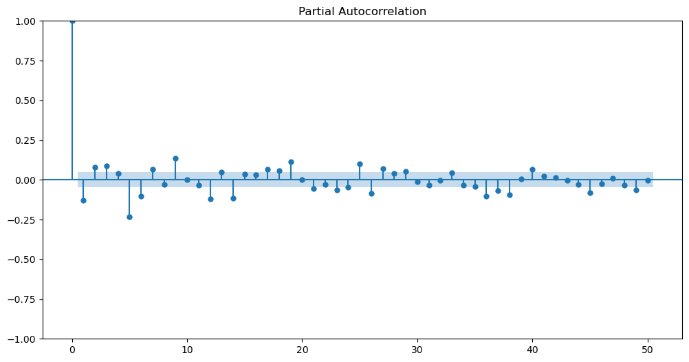

```python
# PACF
fig, ax = plt.subplots(figsize = (12, 6))
plot_pacf(doge_train['Close_diff'], lags = 50, ax = ax)
plt.show()
```

```python
def find_best_ar_lag(series, max_lag=30, plot=True):
    """
    Automatically finds the best lag for an AR model based on AIC and BIC.

    Parameters:
    - series: pd.Series (e.g., differenced 'Close' prices)
    - max_lag: int, maximum lag to evaluate
    - plot: bool, whether to plot AIC/BIC

    Returns:
    - dict with best lags and full score table
    """
    aic_scores = []
    bic_scores = []
    lags = []

    warnings.filterwarnings("ignore")  # suppress convergence warnings

    for lag in range(1, max_lag + 1):
        try:
            model = AutoReg(series, lags=lag, old_names=False).fit()
            aic_scores.append(model.aic)
            bic_scores.append(model.bic)
            lags.append(lag)
        except Exception:
            continue

    results = pd.DataFrame({
        'Lag': lags,
        'AIC': aic_scores,
        'BIC': bic_scores
    }).set_index('Lag')

    best_aic_lag = results['AIC'].idxmin()
    best_bic_lag = results['BIC'].idxmin()

    if plot:
        results.plot(title='AIC and BIC Scores by Lag', figsize=(10, 4), marker='o')
        plt.ylabel('Score (lower is better)')
        plt.grid(True)
        plt.show()

    return {
        'best_aic_lag': best_aic_lag,
        'best_bic_lag': best_bic_lag,
        'results': results
    }
```

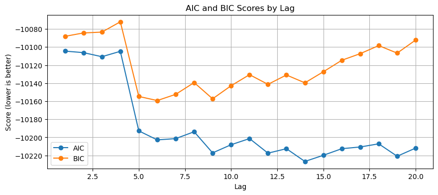

```
Best AIC lag: 14
Best BIC lag: 6
              AIC           BIC
Lag
1   -10104.500298 -10088.158792
2   -10106.176633 -10084.390293
3   -10110.694066 -10083.464059
4   -10104.731307 -10072.058802
5   -10192.792032 -10154.678199
```

```python
# Example: using your differenced Close series
result = find_best_ar_lag(doge_train['Close_diff'], max_lag=20)

print("Best AIC lag:", result['best_aic_lag'])
print("Best BIC lag:", result['best_bic_lag'])
print(result['results'].head())
```

```python
chosen_lag = 14  # we use the best AIC
model = AutoReg(doge_train.Close_diff, lags=chosen_lag).fit()
print(model.summary())
```

```
                            AutoReg Model Results
==============================================================================
Dep. Variable:             Close_diff   No. Observations:                 1716
Model:                    AutoReg(14)   Log Likelihood                5129.324
Method:               Conditional MLE   S.D. of innovations              0.012
Date:                Thu, 22 May 2025   AIC                         -10226.647
Time:                        09:55:11   BIC                         -10139.614
Sample:                    07-20-2019   HQIC                        -10194.429
                         - 03-16-2024
==================================================================================
                     coef    std err          z      P>|z|      [0.025      0.975]
----------------------------------------------------------------------------------
const              0.0001      0.000      0.376      0.707      -0.000       0.001
Close_diff.L1     -0.1243      0.024     -5.160      0.000      -0.172      -0.077
Close_diff.L2      0.1072      0.024      4.414      0.000       0.060       0.155
Close_diff.L3      0.1394      0.024      5.732      0.000       0.092       0.187
Close_diff.L4      0.0427      0.025      1.739      0.082      -0.005       0.091
Close_diff.L5     -0.2329      0.025     -9.484      0.000      -0.281      -0.185
Close_diff.L6     -0.1304      0.025     -5.215      0.000      -0.179      -0.081
Close_diff.L7      0.0252      0.025      0.999      0.318      -0.024       0.075
Close_diff.L8     -0.0020      0.025     -0.081      0.936      -0.052       0.047
Close_diff.L9      0.1251      0.025      4.990      0.000       0.076       0.174
Close_diff.L10     0.0090      0.025      0.365      0.715      -0.039       0.057
Close_diff.L11    -0.0402      0.025     -1.638      0.101      -0.088       0.008
Close_diff.L12    -0.1006      0.024     -4.128      0.000      -0.148      -0.053
Close_diff.L13     0.0343      0.024      1.406      0.160      -0.013       0.082
Close_diff.L14    -0.1170      0.024     -4.825      0.000      -0.165      -0.069
                                    Roots
==============================================================================
                   Real          Imaginary           Modulus         Frequency
------------------------------------------------------------------------------
AR.1            -1.0513           -0.2636j            1.0838           -0.4609
AR.2            -1.0513           +0.2636j            1.0838            0.4609
AR.3            -0.9082           -0.7419j            1.1727           -0.3910
AR.4            -0.9082           +0.7419j            1.1727            0.3910
AR.5            -0.4344           -1.0104j            1.0998           -0.3146
AR.6            -0.4344           +1.0104j            1.0998            0.3146
AR.7             1.1171           -0.2815j            1.1520           -0.0393
AR.8             1.1171           +0.2815j            1.1520            0.0393
AR.9             0.8667           -0.6843j            1.1043           -0.1064
AR.10            0.8667           +0.6843j            1.1043            0.1064
AR.11            0.0226           -1.1989j            1.1991           -0.2470
AR.12            0.0226           +1.1989j            1.1991            0.2470
AR.13            0.5340           -1.2628j            1.3710           -0.1863
AR.14            0.5340           +1.2628j            1.3710            0.1863
------------------------------------------------------------------------------
```

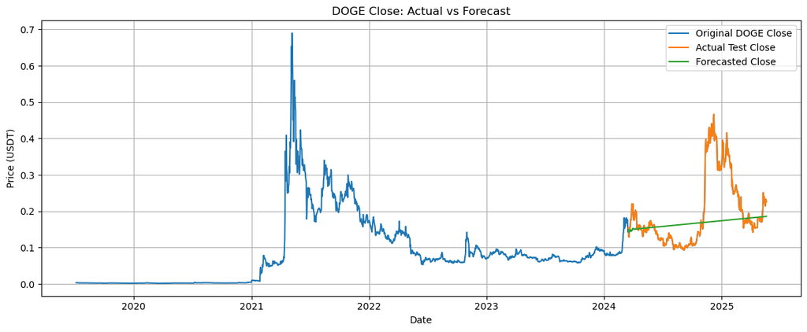

```python
# === Forecast differenced values ===
forecast_steps = len(doge_test)
pred_diff = model.predict(start=len(doge_train), end=len(doge_train) + forecast_steps - 1)

# === Reconstruct forecasted Close prices from differencing ===
# Start from last actual known Close price
last_actual_close = doge_train['Close'].iloc[-1]
forecast_close = pred_diff.cumsum() + last_actual_close

# === Align actual Close from test data ===
actual_close = doge_test['Close']

# === Combine everything for plotting ===
full_close = pd.concat([doge_train['Close'], actual_close])
full_forecast = pd.Series(data=forecast_close.values, index=actual_close.index)

# === Plot ===
plt.figure(figsize=(12, 5))
plt.plot(full_close, label="Original DOGE Close")
plt.plot(actual_close, label="Actual Test Close")
plt.plot(full_forecast, label="Forecasted Close")
plt.title("DOGE Close: Actual vs Forecast")
plt.xlabel("Date")
plt.ylabel("Price (USDT)")
plt.legend()
plt.grid(True)
plt.tight_layout()
plt.show()
```

Underfitting is expected since AR is simple model

# Evaluating

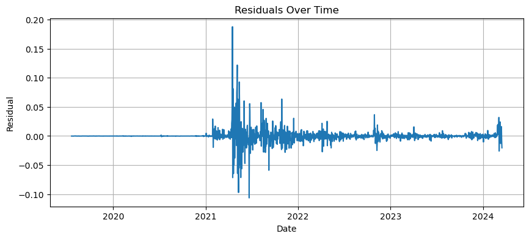

```python
residuals = model.resid
# Only valid if you reconstructed forecasted Close
forecast_resid = doge_test['Close'] - forecast_close
plt.figure(figsize=(10, 4))
plt.plot(residuals)
plt.title("Residuals Over Time")
plt.xlabel("Date")
plt.ylabel("Residual")
plt.grid(True)
plt.show()
```

The residual plot suggests that the model does reasonably well overall, but struggles during extreme market events (like the 2021 DOGE surge). In calmer conditions, it captures price movement more reliably.

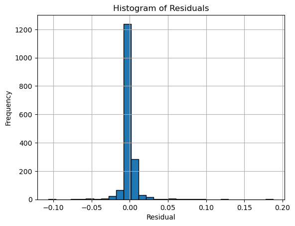

```python
plt.hist(residuals, bins=30, edgecolor='k')
plt.title("Histogram of Residuals")
plt.xlabel("Residual")
plt.ylabel("Frequency")
plt.grid(True)
plt.show()
```

The distribution is centered around 0 howeverit is very narrow and peaked, with a slight right tail. This could indicate non-normality, possibly due to Outliers Very low volatility in most periods, followed by some large jumps.

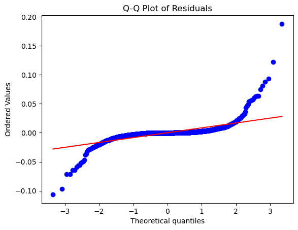

```python
stats.probplot(residuals, dist="norm", plot=pylab)
pylab.title("Q-Q Plot of Residuals")
pylab.show()
```

The residuals are not perfectly normal.

There are fat tails (especially on the right), suggesting occasional large forecast errors.

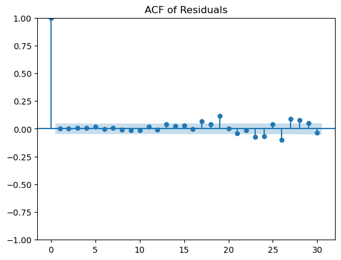

```python
plot_acf(residuals, lags=30)
plt.title("ACF of Residuals")
plt.show()
```